# ЕГЭ 2018 Вариант 13 EGE 2018 Variant 13

Использованы материалы:

The list of used links and books:

[ЕГЭ 2018. Математика. Профильный уровень. 20 вариантов тестов. Тематическая рабочая тетрадь.](https://drive.google.com/file/d/0B8CJrELbJAyodmtvbV8xcEtZXzA/view)

[SymPy Tutorials](http://nbviewer.jupyter.org/url/www.inp.nsk.su/~grozin/python/sympy.ipynb)

[LaTeX Mathematics](https://en.wikibooks.org/wiki/LaTeX/Mathematics)

[ВСТРЕЧИ С ФИНАНСОВОЙ МАТЕМАТИКОЙ](https://ege.sdamgia.ru/doc/math/gushchin_dd-finmatematika.pdf)

## Часть 1 Part 1

```python
%%html
<style>
@import url('https://fonts.googleapis.com/css?family=Roboto&effect=3d|scuffed-steel|static|canvas-print|');
a, h1 h2, h3, h4, div.text_cell_render {font-family: 'Roboto'; text-shadow: 4px 4px 4px #aaa;}

h2, h3, div.output_prompt, div.output_area pre {color: slategray;}
h1, h4, div.input_prompt {color: steelblue;}
a, div.output_subarea {color: darkblue;}

span {text-shadow: 4px 4px 4px #aaa;}

body, div.output_stderr pre{background-color: aliceblue;}
div.output_stderr {background-color: slategray;}
</style>
```

```python
answer_dictionary = dict()
```

[figure not shown]

### Задание 1 / Task 1

В сентябре 1 кг помидоров стоил 70 рублей, в октябре помидоры подорожали на 20%, а в ноябре еще на 25%.

Сколько рублей стоил 1 кг помидоров после подорожания в ноябре?

In September, 1 kg of tomatoes cost 70 rubles, in October tomato prices went up by 20%, and in November - by another 25%.

How many rubles did 1 kg of tomatoes cost in November?

Рост цены на 20% соответствует увеличению в 1,2 раза; на 25% - в 1,25 раза.

The price increase of 20% corresponds to an increase of 1.2 times; on 25% - in 1.25 times.

$70 * 1.2 * 1.25 = 105$ (рублей / rubles)

### Ответ / Answer: 105

```python
answer_dictionary[1]=str(int(70 * 1.2 * 1.25))
```

[figure not shown]

### Задание 2 / Task 2

На рисунке показано изменение температуры воздуха на протяжении трех суток. По горизонтали указывается дата и время, по вертикали - значение температуры в градусах Цельсия.

Определите по рисунку наибольшую температуру воздуха 20 декабря. Ответ дайте в градусах Цельсия.

The picture shows the change in air temperature over the course of three days. The date and time are indicated horizontally, and the temperature in degrees Celsius is indicated vertically.

Determine the highest air temperature on December 20 according to the picture. Give the answer in degrees Celsius.

### Ответ / Answer: 0

```python
answer_dictionary[2]=str(0)
```

[figure not shown]

### Задание 3 / Task 3

На клетчатой бумаге с размером клетки $1 х 1$ изображен квадрат. Найдите его площадь.

On a graph paper with the cell size $1 х 1$ the square is represented. Find its area.

### Ответ: 5

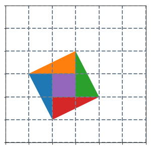

```python
import matplotlib.pyplot as plt
%matplotlib inline

plt.figure(figsize=(5,5))
plt.grid(c='slategray', ls='--', lw=2)

XY = [[[1,2,2], [3,3,1]],
      [[1,3,3], [3,3,4]],
      [[3,3,4], [4,2,2]],
      [[2,2,4], [1,2,2]],
      [[2,2,3,3], [2,3,3,2]]]

for x,y in XY:
    plt.fill(x,y)

plt.xlim(0,6)
plt.ylim(0,6)

plt.xticks(visible=False)
plt.yticks(visible=False);
```

```python
answer_dictionary[3]=str(int(4 * (2 * 1/2) + 1))
```

[figure not shown]

### Задание 4 / Task 4

Перед началом первого тура чемпионата по шашкам участников разбивают на игровые пары случайным образом с помощью жребия.

Всего в чемпионате участвуют 56 шашистов, среди которых 12 участников из России, в том числе Валерий Стремянкин.

Найдите вероятность того, что в первом туре Валерий Стремянкин будет играть с каким-либо шашистом из России.

Before the start of the first round of the checkers' championship, players are split into pairs by randomly drawing lots.

In total 56 players participate in the championship, among them 12 participants from Russia, including Valery Stemyankin.

Find the likelihood that in the first round Valery Strymyankin will play with some Russian player.

У Валерия Стремянкина 55 соперников, из них 11 соотечественников.

Вероятность случайного события "сыграть с партнером из России": 11/55 = 0.2.

Valery Stremyankin has 55 rivals, 11 of them are compatriots.

The probability of an accidental event "to play with a partner from Russia" is: 11/55 = 0.2.

### Ответ / Answer: 0.2

```python
answer_dictionary[4]=str(11/55)
```

[figure not shown]

### Задание 5 \ Task 5

Найдите корень уравнения

Find the root of equation

$2^{5 - x} = 0.25$

```python
%%latex
$2^{5 - x} = 0.25 \\
2^{5 - x} = 2^{-2} \\
5 - x = -2 \\
x = 7$
```

$2^{5 - x} = 0.25 \\ 2^{5 - x} = 2^{-2} \\ 5 - x = -2 \\ x = 7$

### Ответ / Answer: 7

```python
answer_dictionary[5]=str(7)
```

[figure not shown]

### Задание 6 / Task 6

Отрезок $AB$ является хордой окружности с центром $O$.

Найдите угол между прямой $AB$ и касательной к окружности, проходящей через точку $A$, если угол $AOB$ равен $56^o$.

Ответ дайте в градусах.

A segment $AB$ is a chord of a circle with center $O$.

Find the angle between the line $AB$ and the tangent line to the circle passing through the point $A$ if the angle $AOB$ is $56^o$.

Give the answer in degrees.

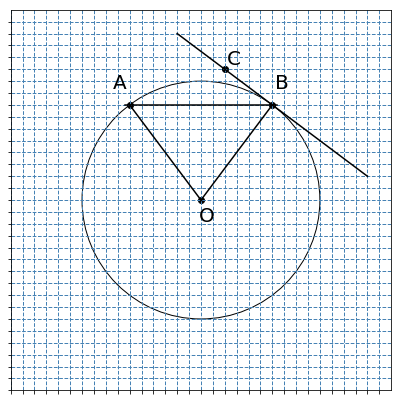

```python
from matplotlib.patches import Circle
import numpy

f = plt.figure(figsize=(7,7))
ax = f.add_subplot(1, 1, 1, aspect=1)
ax.grid(c='steelblue', ls='--', lw=1)

plt.xlim(-8,8)
plt.ylim(-8,8)
plt.xticks(numpy.arange(-8, 8, step=0.5), visible=False)
plt.yticks(numpy.arange(-8, 8, step=0.5), visible=False)

plt.text(-0.1,-0.9,'O', fontsize=20)
plt.text(-3.7,4.7,'A', fontsize=20)
plt.text(3.1,4.7,'B', fontsize=20)
plt.text(1.1,5.7,'C', fontsize=20)

ax.scatter([0,-3,3,1],[0,4,4,5.5], c='black')

ax.axhline(4, 0.3, 0.7, c='black')
ax.plot([0,3],[0,4], c='black')
ax.plot([0,-3],[0,4], c='black')
ax.plot([-1,7],[7,1], c='black')

circle = Circle((0, 0), 5, lw=1,
                edgecolor='black', facecolor='none')
ax.add_artist(circle);
```

$1$. Радиусы окружности $AO = BO \implies \bigtriangleup AOB$ - равнобедренный.

$1$. Radiuses of the circumference $AO = BO \implies \bigtriangleup AOB$ is isosceles.

$\implies \angle OBA = \angle OAB = (180^o - \angle AOB) \ / \ 2 = (180^o - 56^o) \ / \ 2 = 62^o$.

$2$. Касательная $BC$ и радиус $OB$ - перпендикулярны.

$2$. The tangent line $BC$ and the radius $OB$ are perpendicular.

$\implies \angle ABC = 90^o - \angle OBA = 90^o - 62^o = 28^o$

### Ответ / Answer: 28

```python
answer_dictionary[6]=str(int(90-(180-56)/2))
```

[figure not shown]

### Задание 7 / Task 7

На рисунке изображен график функции $y = f(x)$.

Прямая, проходящая через точку $(-1;1)$, касается этого графика в точке с абсциссой $3$.

Найдите $\ f'(3)$.

The figure shows the graph of the function $y = f (x)$.

The line passing through the point $(- 1; 1)$ touches this graph at the point with the abscissa $3$.

Find $\ f '(3 )$.

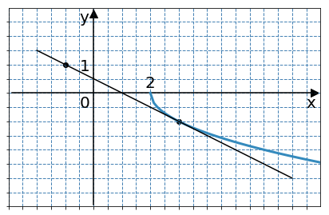

```python
f = plt.figure(figsize=(7,7))
ax = f.add_subplot(1, 1, 1, aspect=1)
ax.grid(c='steelblue', ls='--', lw=1)

plt.xlim(-3,8)
plt.ylim(-4,3)
plt.xticks(numpy.arange(-3, 8, step=0.5), visible=False)
plt.yticks(numpy.arange(-4, 3, step=0.5), visible=False)

ax.scatter(0,2.8, marker='^', s=100, c='black')
ax.scatter(7.8,0, marker='>', s=100, c='black')
ax.scatter([-1,3],[1,-1], c='black')

plt.text(7.5,-0.5,'x', fontsize=20)
plt.text(-0.5,2.5,'y', fontsize=20)
plt.text(1.8,0.2,'2', fontsize=20)
plt.text(-0.5,0.8,'1', fontsize=20)
plt.text(-0.5,-0.5,'0', fontsize=20)

ax.axhline(0, 0.01, 0.99, c='black')
ax.axvline(0, 0.01, 0.99, c='black')

x = numpy.linspace(2,8)
y = -1 * numpy.sqrt(x - 2)
ax.plot(x, y, c='#348ABD', lw=3)
ax.plot([-2,7],[1.5,-3], c='black');
```

Уравнение касательной, проходящей через точки $(-1,1)$ и $(3,-1)$:

The equation of the tangent line passing through the points $(- 1,1)$ and $(3, -1)$:

$\large{\frac{y+1}{1+1} = \frac{x-3}{-1-3}}$ $\iff y = -0.5 * x +0.5$

Коэффициент $-0.5$ в уравнении прямой является тангенсом угла наклона касательной, проведенной к графику функции в определенной точке, и равен производной функции в этой точке:

The coefficient $-0.5$ in the line equation is the tangent of the slope angle for the tangent line drawn to the function graph at a certain point and is equal to the derivative value of the function at this point:

$f'(3) = -0.5$

### Ответ / Answer: -0.5

```python
answer_dictionary[7]=str(-0.5)
```

[figure not shown]

### Задание 8 / Task 8

В сосуде, имеющем форму конуса, уровень жидкости достигает $\large{\frac{1}{4}}$ высоты. Объем жидкости равен $5 \ мл$.

Сколько миллилитров жидкости нужно долить, чтобы наполнить сосуд доверху?

In a vessel having the shape of a cone, the liquid level reaches $\large{\frac{1}{4}}$ height. The volume of the liquid is $5 \ ml$.

How many milliliters of liquid must be added to fill the vessel to the top?

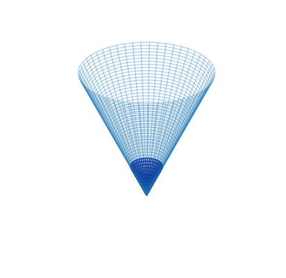

```python
from mpl_toolkits.mplot3d import axes3d
f = plt.figure(figsize=(7,7))
ax = f.add_subplot(111,projection='3d')

theta = numpy.linspace(0,2*numpy.pi,50)
r = numpy.linspace(0,4,50)
T, R = numpy.meshgrid(theta, r)

X = R * numpy.cos(T)
Y = R * numpy.sin(T)
Z = numpy.sqrt(X**2 + Y**2)

ax.plot_wireframe(X, Y, Z, alpha=0.3)
Z[Z>1] = numpy.nan
ax.plot_wireframe(X, Y, Z, colors='darkblue')

# ax.set_zlim(0,4)
plt.axis('off');
```

$V_0 = \pi * r_0^2 * \large{\frac{h_0}{3}}$ $; \ h = 4 * h_0; \ r = 4 * r_0$

$V = \pi * (4 * r_0)^2 * \large{\frac{4 * h_0}{3}}$ $= 4^3 * V_0 = 4^3 * 5 = 320$

$V - V_0 = 320 - 5 = 315$

### Ответ / Answer: 315

```python
answer_dictionary[8]=str(4**3*5 - 5)
```

[figure not shown]

### Задание 9 / Task 9

Найдите значение выражения

Find the value of the expression $log_3{11} * log_{11}{27}$.

```python
%%latex
$ log_3{11} * log_{11}{27} = log_3{11} * log_3{27} \ / \ log_3{11} = log_3{27} = 3$
```

$ log_3{11} * log_{11}{27} = log_3{11} * log_3{27} \ / \ log_3{11} = log_3{27} = 3$

### Ответ / Answer: 3

```python
import math
answer_dictionary[9]=str(int(math.log(11,3) * math.log(27,11)))
```

[figure not shown]

### Задание 10 / Task 10

Высоту над землей (в метрах) подброшенного вверх камня можно вычислять по формуле $h(t) = 1.4 + 14 * t - 5 * t^2$, где t - время в секундах.

Сколько секунд камень будет находиться на высоте более 8 метров?

The height above the ground (in meters) of the stone thrown up can be calculated from the formula $h(t) = 1.4 + 14 * t - 5 * t^2$, where t is the time in seconds.

How many seconds will the stone be at an altitude of more than 8 meters?

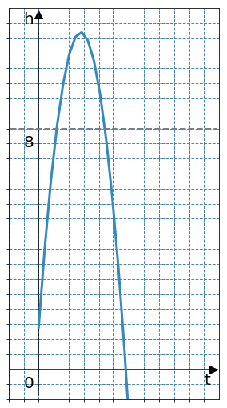

```python
f = plt.figure(figsize=(9,9))
ax = f.add_subplot(1, 1, 1, aspect=1)
ax.grid(c='steelblue', ls='--', lw=1)

plt.xlim(-1,6)
plt.ylim(-1,12)
plt.xticks(numpy.arange(-1, 6, step=0.5), visible=False)
plt.yticks(numpy.arange(-1, 12, step=0.5), visible=False)

ax.scatter(0,11.8, marker='^', s=100, c='black')
ax.scatter(5.8,0, marker='>', s=100, c='black')
plt.text(5.5,-0.5,'t', fontsize=20)
plt.text(-0.5,11.5,'h', fontsize=20)
plt.text(-0.5,-0.6,'0', fontsize=20)
plt.text(-0.5,7.4,'8', fontsize=20)
ax.axhline(0, 0.01, 0.99, c='black')
ax.axvline(0, 0.01, 0.99, c='black')

def h(t): return 1.4 + 14 * t - 5 * t ** 2

T = numpy.linspace(0,10)
H = [h(t) for t in T]
ax.plot(T, H, c='#348ABD', lw=3)
ax.axhline(8,0.01,0.99,c='slategray',ls='--',lw=2);
```

```python
%%latex
$1.4 + 14 * t - 5 * t^2 = 8 \\
14 * t - 5 * t^2 - 6.6 = 0 \\
t^2 - 2.8 * t + 1.32 = 0 \\

D = 2.8^2 - 4 * 1.32 = 2.56 \\

\large{t_1 = \frac{2.8 - \sqrt{2.56}}{2} = 0.6 \\
 t_2 = \frac{2.8 + \sqrt{2.56}}{2} = 2.2 }\\

t_2 - t_1 = 2.2 - 0.6 = 1.6$
```

$1.4 + 14 * t - 5 * t^2 = 8 \\ 14 * t - 5 * t^2 - 6.6 = 0 \\ t^2 - 2.8 * t + 1.32 = 0 \\ D = 2.8^2 - 4 * 1.32 = 2.56 \\ \large{t_1 = \frac{2.8 - \sqrt{2.56}}{2} = 0.6 \\ t_2 = \frac{2.8 + \sqrt{2.56}}{2} = 2.2 }\\ t_2 - t_1 = 2.2 - 0.6 = 1.6$

### Ответ / Answer: 1.6

```python
answer_dictionary[10]=str(round(math.sqrt(2.8**2 - 4 * 1.32),2))
```

[figure not shown]

### Задание 11 / Task 11

Из пункта А круговой трассы, длина которой равна 30 км, одновременно в одном направлении стартовали два автомобилиста. Скорость первого равна 92 км/ч, скорость второго - 77 км/ч.

Через сколько минут первый автомобилист будет опережать второго ровно на 1 круг?

From point A of the circular track, the length of which is 30 km, simultaneously in one direction two cars started. The speed of the first is 92 km/h, the speed of the second is 77 km/h.

After how many minutes the first car will be ahead of the second exactly 1 round?

30 / (92 - 77) = 2 (часа / hours)

2 * 60 = 120 (минут / minutes)

### Ответ / Answer: 120

```python
answer_dictionary[11]=str(int(60 * 30 / (92 - 77)))
```

[figure not shown]

### Задание 12 / Task 12

Найдите наибольшее значение функции $y = 13 * x - 13* tg \ x - 18$ на отрезке $[0; \large{\frac{\pi}{4}]}$.

Find the largest value of the function $y = 13 * x - 13* tg \ x - 18$ on the interval $[0; \large{\frac{\pi}{4}]}$.

```python
def y(x): return 13 * x - 13 * math.tan(x) - 18
```

Наибольшего и наименьшего значений непрерывная функция может достигать:

- на концах отрезка,
- в стационарных или критических точках (производная равна 0 или не существует).

The largest and smallest values can be for the continuous function:

- at the ends of the segment,
- at stationary or critical points (the derivative is 0 or does not exist).

```python
y(0)
```

```
-18.0
```

```python
y(math.pi/4)
```

```
-20.78982387583317
```

```python
%%latex
$Производная \ равна \ нулю: \ \mid \ The \ derivative \ is \ 0:\\
y'(x) = 13 - \large{\frac{13}{cos^2(x)}} = 0 \\
cos^2 \ x = 1 \iff cos \ x = 1 \lor cos \ x = -1 \\
x = 2 * \pi * n \ \lor \ x = \pi + 2 * \pi * n, \ n \in \mathbb{Z}$
```

$Производная \ равна \ нулю: \ \mid \ The \ derivative \ is \ 0:\\ y'(x) = 13 - \large{\frac{13}{cos^2(x)}} = 0 \\ cos^2 \ x = 1 \iff cos \ x = 1 \lor cos \ x = -1 \\ x = 2 * \pi * n \ \lor \ x = \pi + 2 * \pi * n, \ n \in \mathbb{Z}$

```python
%%latex
$Производная \ не \ существует: \ \mid \ The \ derivative \ does \ not \ exist: \\
\nexists \ y'(x) \iff cos \ x = 0 \\
x = \large {\frac {\pi}{2}} \normalsize { + \pi * k, \ k \in \mathbb{Z}}$
```

$Производная \ не \ существует: \ \mid \ The \ derivative \ does \ not \ exist: \\ \nexists \ y'(x) \iff cos \ x = 0 \\ x = \large {\frac {\pi}{2}} \normalsize { + \pi * k, \ k \in \mathbb{Z}}$

```python
%%latex
$\large{x \in [0; \frac{\pi}{4}]} \implies y'(0) = 0$
```

$\large{x \in [0; \frac{\pi}{4}]} \implies y'(0) = 0$

### Ответ / Answer: -18

```python
answer_dictionary[12]=str(int(y(0)))
```

## Часть 2 Part 2

[figure not shown]

### Задание 13 / Task 13

a) Найдите корень уравнения:

a) Find the root of the equation:

$7 * sin^2 x + 8 * cos \ x - 8 = 0$.

б) Найдите все корни этого уравнения, принадлежащие промежутку

b) Find all the roots of this equation that belong to the interval

$\large{[-\frac{\pi}{2};\frac{\pi}{2}]}$.

```python
%%latex
$ а) \\
7 * sin^2 x + 8 * cos \ x - 8 = 0 \\
7 * (1 - cos^2 x) + 8 * cos \ x - 8 = 0 \\
7 * cos^2 x - 8 * cos \ x + 1 = 0 \\
D = (-8)^2 - 4 * 7 * 1 = 36 \\
cos \ x = \frac{8 + \sqrt{36}}{2 * 7} = 1 \ \lor \
cos \ x = \frac{8 - \sqrt{36}}{2 * 7} = \frac{1}{7} \\

x = 2 * \pi * n, \ n \in \mathbb{Z} \ \lor \
x = \pm \arccos \frac{1}{7} + 2 * \pi * k, \ k \in \mathbb{Z} \\

б) \\
x \in \large{[-\frac{\pi}{2};\frac{\pi}{2}]} \\
x = 0 \ \lor \ x = \pm \arccos \frac{1}{7}
$
```

$ а) \\ 7 * sin^2 x + 8 * cos \ x - 8 = 0 \\ 7 * (1 - cos^2 x) + 8 * cos \ x - 8 = 0 \\ 7 * cos^2 x - 8 * cos \ x + 1 = 0 \\ D = (-8)^2 - 4 * 7 * 1 = 36 \\ cos \ x = \frac{8 + \sqrt{36}}{2 * 7} = 1 \ \lor \ cos \ x = \frac{8 - \sqrt{36}}{2 * 7} = \frac{1}{7} \\ x = 2 * \pi * n, \ n \in \mathbb{Z} \ \lor \ x = \pm \arccos \frac{1}{7} + 2 * \pi * k, \ k \in \mathbb{Z} \\ б) \\ x \in \large{[-\frac{\pi}{2};\frac{\pi}{2}]} \\ x = 0 \ \lor \ x = \pm \arccos \frac{1}{7} $

```python
- math.pi / 2, - math.acos(1/7), 0, math.acos(1/7), math.pi / 2
```

```
(-1.5707963267948966,
 -1.4274487578895312,
 0,
 1.4274487578895312,
 1.5707963267948966)
```

### Ответ / Answer:

$а) \ 2 * \pi * n, \ \pm \arccos \frac{1}{7} + 2 * \pi * k; \ n, k \in \mathbb{Z}; \ б) \ 0, \ \pm \arccos \frac{1}{7}$.

```python
answer_dictionary[13] = 'а)2∗π∗n, ±arccos(1/7)+2∗π∗k; n,k∈ℤ; б)0, ±arccos(1/7)'
```

[figure not shown]

### Задание 14 / Task 14

Площадь основания правильной четырёхугольной пирамиды SABCD равна 64.

a) Постройте прямую пересечения плоскости SAC и плоскости, проходящей через вершину S этой пирамиды, середину стороны AB и центр основания.

б) Найдите площадь боковой поверхности этой пирамиды, если площадь сечения пирамиды плоскостью SAC равна 64.

The area of the base of the regular quadrangular pyramid SABCD is 64.

a) Construct the intersection of the plane SAC and the plane passing through the vertex S of this pyramid, the middle of the side AB and the center of the base.

b) Find the area of the lateral surface of this pyramid if the cross-sectional area of the pyramid by the SAC plane is 64.

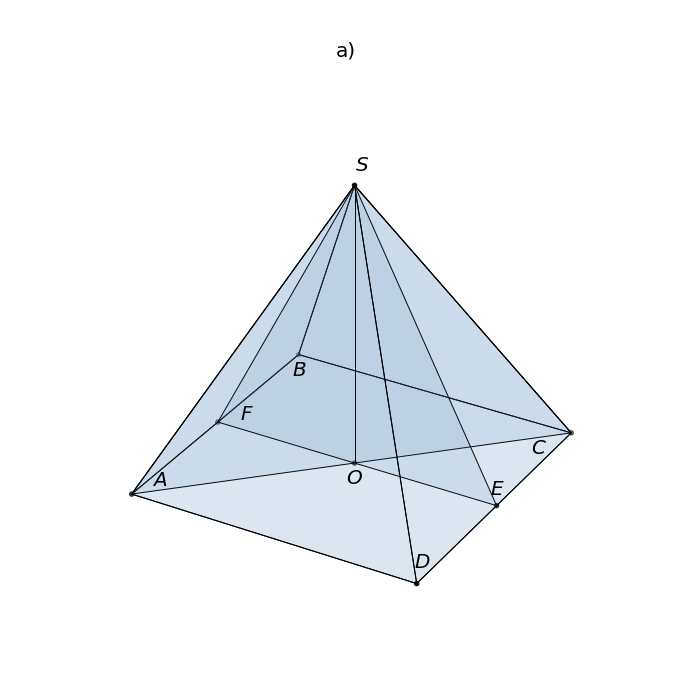

```python
from mpl_toolkits.mplot3d.art3d import Poly3DCollection, Line3DCollection

f = plt.figure(figsize=(12,12))
ax = f.add_subplot(111, projection='3d')

v = numpy.array([[-1,-1,-1], [1,-1,-1], [1,1,-1],  [-1,1,-1], [0,0,1],
                 [-1,0,-1],[1,0,-1],[0,0,-1]])
ax.scatter3D(v[:, 0], v[:, 1], v[:, 2], color='black')

ax.text(0, 0, 1.1, r'$S$', color='black', fontsize=20)
ax.text(0, -0.1, -1.1, r'$O$', color='black', fontsize=20)
ax.text(-0.95, -0.85, -1, r'$A$', color='black', fontsize=20)
ax.text(-0.9, 0.75, -1, r'$B$', color='black', fontsize=20)
ax.text(0.9, 0.65, -1, r'$C$', color='black', fontsize=20)
ax.text(0.9, -0.85, -1, r'$D$', color='black', fontsize=20)
ax.text(-0.9, 0.1, -1, r'$F$', color='black', fontsize=20)
ax.text(0.9, 0.1, -1, r'$E$', color='black', fontsize=20)

verts = [ [v[0],v[1],v[4]], [v[0],v[3],v[4]],
          [v[2],v[1],v[4]], [v[2],v[3],v[4]],
          [v[0],v[1],v[2],v[3]], [v[4],v[7]],
          [v[4],v[5],v[6]], [v[4],v[0],v[2]] ]

piramid = Poly3DCollection(verts, lw=1, alpha=0.1,
                           edgecolors='black', facecolor='none')
piramid.set_facecolor('steelblue')
ax.add_collection3d(piramid)

plt.title('a)', fontsize=20)
plt.axis('off')
plt.show()
```

б)

$SABCD$ - правильная пирамида $\implies ABCD$ - квадрат

$SABCD$ - a right regular pyramid $\implies ABCD$ - a square

$\implies AB = BC = CD = AD = \sqrt{64} = 8 \implies AC = \sqrt{8^2 + 8^2} = 8 \sqrt{2}$

$O$ - центр основания правильной пирамиды

$O$ - a center of the base for the right regular pyramid

$\implies SO \bot OC \implies SO = 2 * S_{\bigtriangleup SAC} / AC = 2 * 64 / 8 \sqrt{2} = 8 \sqrt{2}$

$AO = OC, \ AF = FB \implies FO = 8 / 2 = 4$

$SO \bot FO \implies FS = \sqrt{(8\sqrt{2})^2 + 4^2} = 12$

$SA = SB, \ AF = FB \implies FS \bot AB \implies S_{\bigtriangleup SAB} = FS * AB / 2 = 12 * 8 / 2 = 48$

$S_{ls} = 4 * S_{\bigtriangleup SAB} = 4 * 48 = 192$

### Ответ / Answer: 192

```python
answer_dictionary[14] = str(192)
```

[figure not shown]

### Задание 15 / Task 15

Решите неравенство:

Solve the inequality:

$\large{\log_{x + 2}^2 {(x - 18)^2} + 32 \leq 16 * \log_{x + 2} {(36 + 16 * x - x^2)}}$

1) Область допустимых значений: / Range of admissible values:

$\begin{cases} x + 2 > 0 \\ x + 2 \neq 1 \\ (x-18)^2 >0 \\ 36 + 16 * x - x^2 > 0\end{cases} \iff \ \begin{cases} x > -2 \\ x \neq -1 \\ x \neq 18 \\ x^2 - 16 * x - 36 < 0\end{cases} \iff \begin{cases} x > -2 \\ x \neq -1 \\ x \neq 18 \\ (x - 18) * (x + 2) < 0\end{cases} \iff \begin{cases} -2 < x < -1 \\ -1 < x < 18 \end{cases}$

2) Преобразования неравенства: / Inequality transformations:

$\log_{x+2}^2 {(x - 18)^2} + 32 - 16 * \log_{x+2} {(36 + 16 * x - x^2)} \leq 0 \iff \log_{x+2}^2 {(18 - x)^2} + 32 - 16 * \log_{x+2} {((18 - x) * (x + 2))} \leq 0 \iff$

$\log_{x+2}^2 {(18 - x)^2} + 32 - 16 * \log_{x+2} {(x+2)} - 16 * \log_{x+2} {(18 - x)} \leq 0 \iff \log_{x+2}^2 {(18 - x)^2} + 32 - 16 - 16 * \log_{x+2} {(18 - x)} \leq 0 \iff$

$\log_{x+2}^2 {(18 - x)^2} - 16 * \log_{x+2} {(18 - x)} + 16 \leq 0 \iff \log_{x+2}^2 {(18 - x)^2} - 8 * \log_{x+2} {(18 - x)^2} + 16 \leq 0 \iff$

$ (\log_{x+2} {(18 - x)^2} - 4)^2 \leq 0 \iff log_{x+2} {(18 - x)^2} - 4 = 0 \iff log_{x+2} {(18 - x)} = 2$

$ (x + 2)^2 + x - 18 = 0 \iff x^2 + 5 * x - 14 = 0 \iff x = 2 \ \lor \ x = -7$

$x = -7$ не попадает в область допустимых значений. / $x = -7$ does not fall within the range of allowed values.

### Ответ / Answer: 2

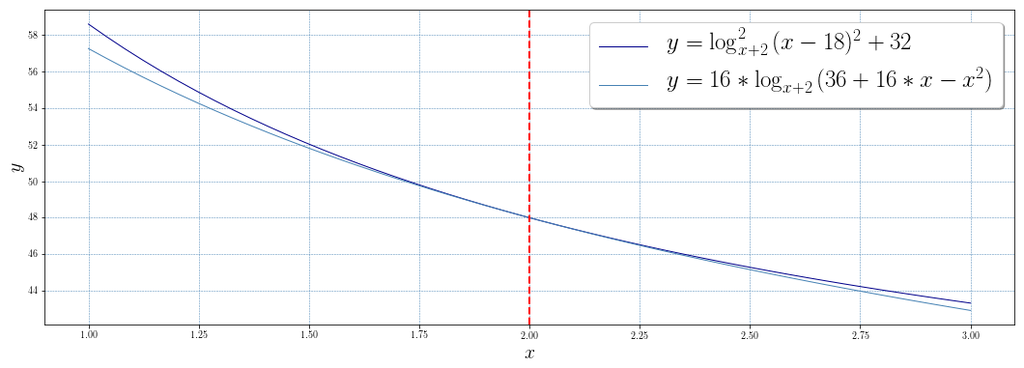

```python
from sympy import log
import matplotlib
from __future__ import unicode_literals

matplotlib.rcParams['text.usetex'] = True
matplotlib.rcParams['text.latex.unicode'] = True

x = numpy.linspace(1,3)
y = numpy.linspace(42,60)
y1 = [log((el-18)**2,el+2)**2+32 for el in x]
y2 = [16*log(36+16*el-el**2,el+2) for el in x]

plt.figure(figsize=(18,6))
plt.plot(x, y1, c='darkblue', lw=1, label=r'$y = \log_{x + 2}^2 {(x - 18)^2} + 32$')
plt.plot(x, y2, c='steelblue', lw=1, label=r'$y = 16 * \log_{x + 2} {(36 + 16 * x - x^2)}$')

plt.grid(c='steelblue', ls='--', lw=0.5)
plt.axvline(2.0, c='r', ls='--', lw=2)

plt.xlabel(r'$x$', fontsize=20)
plt.ylabel(r'$y$', fontsize=20)
plt.legend(fontsize=25, shadow=True);
```

```python
answer_dictionary[15] = str(2)
```

[figure not shown]

### Задание 16 / Task 16

[Задание C4 №17](http://live.mephist.ru/show/mathege-solutions/id/17/)

Точка $O$ - центр окружности радиуса $2$. На продолжении радиуса $OM$ взята точка $A$.

Через точку $A$ проведена прямая, касающаяся окружности в точке $K$. Известно, что $\angle OAK = 60^o$.

a) Докажите, что $AK = \large{\frac{2 \sqrt{3}}{3}}$.

б) Найдите радиус окружности, вписанной в угол OAK и касающейся данной окружности внешним образом.

The point $O$ is the center of the circle of radius $2$. On the continuation of the radius $OM$, the point $A$ is taken.

A straight line tangent to the circle at the point $K$ is drawn through the point $A$. It is known that $\angle OAK = 60^o$.

a) Prove that $\ AK = \large{\frac{2 \sqrt{3}}{3}}$.

b) Find the radius of the circle inscribed in the angle OAK and touching this circle externally.

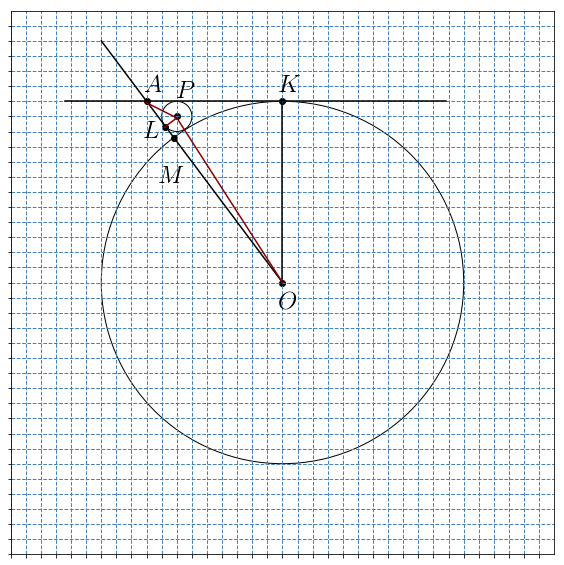

```python
f = plt.figure(figsize=(10,10))
ax = f.add_subplot(1, 1, 1, aspect=1)
ax.grid(c='steelblue', ls='--', lw=1)

plt.xlim(-9,9)
plt.ylim(-9,9)
plt.xticks(numpy.arange(-9, 9, step=0.5), visible=False)
plt.yticks(numpy.arange(-9, 9, step=0.5), visible=False)

plt.text(-0.1,-0.9,r'$O$', fontsize=25)
plt.text(-4.1,3.3,r'$M$', fontsize=25)
plt.text(-4.6,6.3,r'$A$', fontsize=25)
plt.text(-0.1,6.3,r'$K$', fontsize=25)
plt.text(-4.6,4.8,r'$L$', fontsize=25)
plt.text(-3.5,6.1,r'$P$', fontsize=25)

ax.scatter([0,-3.6,0,-4.5,-3.5,-3.9],[0,4.8,6,6,5.5,5.15], c='black')

ax.axhline(6, 0.1, 0.8, c='black')
ax.axvline(0, 0.5, 0.83, c='black')
ax.plot([0,-6],[0,8], c='black')
ax.plot([-3.5,-4.5],[5.45,5.95], c='darkred')
ax.plot([-3.5,-3.9],[5.45,5.15], c='darkred')
ax.plot([0,-3.5],[0,5.45], c='darkred')

circle = Circle((0, 0), 6, lw=1,
                edgecolor='black', facecolor='none')
circle2 = Circle((-3.5, 5.5), 0.5, lw=1,
                edgecolor='black', facecolor='none')
ax.add_artist(circle)
ax.add_artist(circle2);
```

a)

$AK$ - касательная к окружности, $OK$ - её радиус $\implies OK \bot AK, \bigtriangleup OAK$ - прямоугольный $\implies AK = OK \ / \ tg \angle OAK = \frac{2 \sqrt{3}}{3}$

б)

Найдем $OL$ - радиус окружности, вписанной в $\angle OAK$.

$\bigtriangleup APL: PL \bot AL, \ \angle LAP = \angle OAK / 2 = 30^o \implies AL = PL \ / \ tg \ 30^o = \sqrt{3} * PL$

$\bigtriangleup OAK: OA = AK \ / \ sin \ 30^o = \frac{4 \sqrt{3}}{3}$

$\bigtriangleup OPL: r = PL; OP = 2 + PL; OL = OA - AL = \frac{4 \sqrt{3}}{3} - \sqrt{3} * PL \implies$

$PL^2 + (\frac{4 \sqrt{3}}{3} - \sqrt{3} * PL)^2 = (2 + PL)^2$

$4 * PL^2 - 8 * PL + \frac{16}{3}= 4 + 4 * PL + PL^2$

$9 * PL^2 - 36 * PL + 4 = 0$

$D = 36^2 - 4 * 9 * 4 = 1152$

$r = PL = (36 \pm \sqrt{1152}) / (2 * 9) = 2 \pm \frac{4 \sqrt{2}}{3}$

```python
answer_dictionary[16] = '2±4√2/3'
```

[figure not shown]

### Задание 17 / Task 17

15-го января планируется взять кредит в банке на 19 месяцев. Условия его возврата таковы:

- 1-го числа каждого месяца долг возрастает на 3% по сравнению с концом предыдущего месяца;
- со 2-го по 14-е число каждого месяца необходимо выплатить часть долга;
- 15-го числа каждого месяца долг должен быть на одну и ту же величину меньше долга на 15-е число предыдущего месяца.

Сколько процентов от суммы кредита составляет общая сумма денег, которую нужно выплатить банку за весь срок кредитования?

On January 15, it is planned to take out a loan in the bank for 19 months. The conditions for his return are as follows:

- On the first day of each month, debt increases by 3% compared to the end of the previous month;
- from the 2nd to the 14th of each month, it is necessary to pay a part of the debt;
- On the 15th day of each month, the debt should be on the same amount less than the debt on the 15th day of the previous month.

How much is the total amount of money (in the percentage of the loan) that you need to pay the bank for the entire loan period?

Кредит возвращается $19$ равными платежами по $1/19$ от суммы кредита $Х$ и начисленных за весь период процентов:

- в первом месяце процентов начисляется $0.03 * Х$
- после уплаты части долга во втором месяце начисляется на $1/19$ меньше процентов $0.03 * \ \frac{18}{19} * Х$
- в третьем месяце $0.03 * \ \frac{17}{19} * Х$
- ...
- последнее начисление процентов $0.03 * \ \frac{1}{19} * Х$

Сумма всех начисленных процентов составит

$\large{0.03 * Х * (1 + \frac{18}{19} + ... + \frac{1}{19}) = 0.03 * Х * \frac{1 + \frac{1}{19}}{2} * 19 = 0.03 * Х * \frac{20}{19*2} * 19 = 0.03 * Х * 10 = 0.3 * Х}$

$0.3 * Х$ составляет 30 процентов от размера кредита $Х$.

The loan is returned by $19$ equal installments - $1/19$ of the loan amount $X$ and the interest accrued for the entire period:

- in the first month, the interest is charged $0.03 * X$
- after paying a part of the debt in the second month, it becomes $0.03 * \ \frac {18}{19} * X$
- in the third month, $0.03 * \ \frac {17} {19} * X$
- ...
- the last accrual of interest $0.03 * \ \frac {1} {19} * X$

The amount of all accrued interest will be

$\large{0.03 * Х * (1 + \frac{18}{19} + ... + \frac{1}{19}) = 0.03 * Х * \frac{1 + \frac{1}{19}}{2} * 19 = 0.03 * Х * \frac{20}{19*2} * 19 = 0.03 * Х * 10 = 0.3 * Х}$

$0.3 * X$ is 30 percent of the loan size $X$.

### Ответ / Answer: 30.

```python
answer_dictionary[17] = str(30)
```

[figure not shown]

### Задание 18 / Task 18

Найдите все значения параметра $k$, при каждом из которых уравнение

$\large{\frac{2 + (4 - 4 * k) * cos \ t}{4 * cos \ t - sin \ t} = 1} \ (*)$

**не имеет решений** на интервале $\large{\Big(- \pi; - \frac{\pi}{2}\Big)}$.

Find all values of the parameter $ k $, for each of which the equation

$ \large{\frac{2 + (4 - 4 * k) * cos \ t}{4 * cos \ t - sin \ t} = 1} \ (*)$

**has no solutions** on the interval $\large{\Big(- \pi; - \frac{\pi}{2}\Big)}$.

```python
-math.pi, -math.pi/2
```

```
(-3.141592653589793, -1.5707963267948966)
```

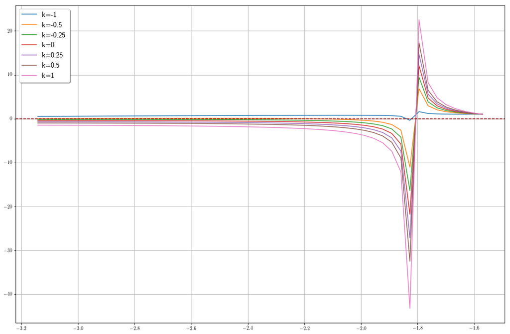

```python
def F(x,k): return (2 + (4 - 4 * k) * math.cos(x))/(4 * math.cos(x) - math.sin(x)) - 1
X = numpy.linspace(-math.pi, -math.pi/2)

plt.figure(figsize=(18,12))
for k in [-1, -0.5, -0.25, 0, 0.25, 0.5, 1]:
    plt.plot(X, [F(x,k) for x in X], label='k='+str(k))

plt.axhline(0, c='darkred', ls='--')
plt.legend(shadow=True, loc=2, fontsize=15)
plt.grid(True)
```

1) Область допустимых значений / Range of admissible values

I.

$(*)$ не имеет решений при любом $k$ на интервале $\large{\Big(- \pi; - \frac{\pi}{2}\Big)}$, если

$(*)$ does not have solutions for any $k$ on the interval $\large{\Big(- \pi; - \frac{\pi}{2}\Big)}$ if

$4 * cos \ t - sin \ t = 0 \\ 4 * cos \ t = sin \ t \\ 16 * cos^2 t = sin^2 t \\ 16 * cos^2 t = 1 - cos^2 t \\ 17 * cos^2 t = 1 \\ cos \ t = - \frac{1}{\sqrt{17}}$

$2 + (4 - 4 * k) * (-\frac{1}{\sqrt{17}}) = 0 \\ (4 * k - 4) * \frac{1}{\sqrt{17}} = -2 \\ k - 1 = -\frac{\sqrt{17}}{2} \\ k = 1 - \frac{\sqrt{17}}{2}$

II. $-1 < \sin t < 0; -1 < \cos t < 0; \; \forall t \in$$\large{\Big(- \pi; - \frac{\pi}{2}\Big)}$.

III. $\cos^2 t + \sin^2 t = 1$

2) Преобразования уравнения / The transformations of the equation

$4 * cos \ t - sin \ t \neq 0 \implies (*) \equiv 2 + (4 - 4 * k) * cos \ t = 4 * cos \ t - sin \ t$

$sin \ t = 4 * k * cos \ t - 2 \; (**)$

3)

$(**)$ задает на плоскости с координатами $(\cos t, \sin t)$ группу прямых, проходящих через точку (0;-2).

Исходное уравнение не имеет решений, если эти прямые

- не пересекают единичную окружность $\cos^2 t + \sin^2 t = 1$,
- точки пересечения не лежат в третьей координатной четверти $-1 < \sin t < 0; -1 < \cos t < 0$.

Для удобства вычислений в данной задаче $\cos t$ отмечен на оси абсцисс, $\sin t $ - на оси ординат.

$(*)$ defines on the plane with coordinates $(\cos t, \sin t)$ the group of lines passing through the point (0; -2).

The original equation has no solutions if these lines

- do not intersect the unit circle $\cos^2 t + \sin^2 t = 1$,
- the intersection points do not lie in the third coordinate quarter $-1 < \sin t < 0; -1 < \cos t < 0$.

For convenience of calculations in the given problem $\cos t$ marks on the abscissa, $\sin t$ - on the ordinate axis.

4)

$k = 1 - \frac{\sqrt{17}}{2} \implies \sin \ t = (4 - 2\sqrt{17}) * \cos \ t - 2$

5)

Найдем $k$, для которых дискриминант уравнения отрицательный:

Let's find $ k $ for which the discriminant of the equation is negative:

$sin \ t = 4 * k * cos \ t - 2 \\ 16 * k^2 * cos^2 t - 16 * k * cos \ t + 4 = 1 - cos^2 t \\ (16 * k^2 + 1) * cos^2 t - 16 * k * cos \ t + 3 = 0$

$D = (16 * k)^2 - 4 * (16 * k^2 + 1) * 3 = 64 * k^2 - 12$

$64 * k^2 - 12 < 0 \\ 64 * k^2 < 12 \\ k^2 < \frac{3}{16} \\ -\frac{\sqrt{3}}{4} < k < \frac{\sqrt{3}}{4}$

$k = -\frac{\sqrt{3}}{4} \implies \sin \ t = -\sqrt{3} * \cos \ t - 2$

$k = \frac{\sqrt{3}}{4} \implies \sin \ t = \sqrt{3} * \cos \ t - 2$

6)

Для данного промежутка нет решений уравнения в третьей координатной четверти:

For the given interval there are no solutions of the equation in the third coordinate quarter:

$k \geq \frac{\sqrt{3}}{4}: for \; example, \; k = 1 \implies \sin \ t = 4 * \cos \ t - 2$

7)

Построим прямые, для которой решение существует:

Let's construct the straight lines for which the solution exists:

$k = -0.5 \implies \sin \ t = -2 * \cos \ t - 2$,

$k = -1.5 \implies \sin \ t = -6 * \cos \ t - 2$,

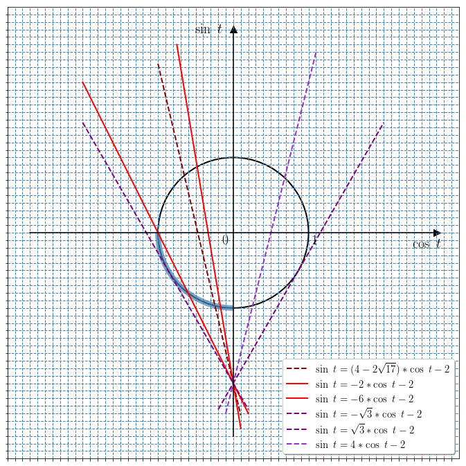

```python
import matplotlib.patches as pat
f = plt.figure(figsize=(12,12))
ax = f.add_subplot(1, 1, 1, aspect=1)
ax.grid(c='steelblue', ls='--', lw=1)

circle = pat.Circle((0, 0), 1, lw=2,
                edgecolor='black', facecolor='none')
arc = pat.Arc((0, 0), 2, 2, lw=8, alpha=0.7,
              theta1=180, theta2=270,
              edgecolor='steelblue',
              facecolor='none')
ax.add_artist(circle)
ax.add_artist(arc)

ax.plot([-1,0.1],[(4-2*math.sqrt(17))*(-1)-2,(4-2*math.sqrt(17))*0.1-2],
        ls='--',lw=2,c='darkred',label=r'$\sin \ t = (4 - 2\sqrt{17}) * \cos \ t - 2$')
ax.plot([-2,0.2],[-2*(-2)-2,-2*0.2-2],ls='-',lw=2,c='red',
        label=r'$\sin \ t = -2 * \cos \ t - 2$')
ax.plot([-0.75,0.1],[-6*(-0.75)-2,-6*0.1-2],ls='-',lw=2,c='red',
        label=r'$\sin \ t = -6 * \cos \ t - 2$')
ax.plot([-2,0.2],[-math.sqrt(3)*(-2)-2,-math.sqrt(3)*0.2-2],ls='--',lw=2,c='purple',
        label=r'$\sin \ t = -\sqrt{3} * \cos \ t - 2$')
ax.plot([-0.2,2],[math.sqrt(3)*(-0.2)-2,math.sqrt(3)*2-2],ls='--',lw=2,c='purple',
        label=r'$\sin \ t = \sqrt{3} * \cos \ t - 2$')
ax.plot([-0.1,1.1],[4*(-0.1)-2,4*1.1-2],ls='--',lw=2,c='darkorchid',
        label=r'$\sin \ t = 4 * \cos \ t - 2$')

ax.axhline(0,0.05,0.95,c='black')
ax.axvline(0,0.05,0.95,c='black')
plt.text(-0.15,-0.15,r'$0$', fontsize=20)
plt.text(1.05,-0.15,r'$1$', fontsize=20)

plt.text(2.38,-0.19,r'$\cos \ t$', fontsize=20)
plt.text(-0.5,2.65,r'$\sin \ t$', fontsize=20)
ax.scatter(0,2.71, marker='^', s=100, c='black')
ax.scatter(2.71,0, marker='>', s=100, c='black')

plt.legend(shadow=True, loc=4, fontsize=15)
plt.xlim(-3,3)
plt.ylim(-3,3)
plt.xticks(numpy.arange(-3, 3, step=0.1), visible=False)
plt.yticks(numpy.arange(-3, 3, step=0.1), visible=False);
```

### Ответ / Answer:

$k = 1 - \frac{\sqrt{17}}{2}; \; k > -\frac{\sqrt{3}}{4}$

```python
1 - math.sqrt(17)/2, -math.sqrt(3)/4, math.sqrt(3)/4
```

```
(-1.0615528128088303, -0.4330127018922193, 0.4330127018922193)
```

```python
answer_dictionary[18] = 'k=1-√17/2; k>-√3/4'
```

[figure not shown]

### Задание 19 / Task 19

Какое наибольшее количество чисел можно выбрать из отрезка натурального ряда от $1$ до $2009$ так,

чтобы разность любых двух из них **не была** простой?

What is the largest quantity of natural numbers you can choose from a segment from $1$ to $2009$

so that the difference between any two of them **was not** a prime number?

Чтобы разность между любыми двумя числами натурального ряда $1, 2, ..., 2009$ **всегда не была** простым числом,

она никогда не должна быть меньше 4.

Рассмотрим возможные варианты, когда разность кратна 4:

- выбираем все нечетные числа вида 4 * n + 1; n=0,1,2... : $1, 5, ..., 2009$
  - (2009 - 1) / 4 + 1 = 503 числа;
- выбираем все четные числа вида 4 * n + 2; n=0,1,2,... : $2, 6, ..., 2006$
  - (2006 - 2) / 4 + 1 = 502 числа;
- выбираем все нечетные числа вида 4 * n + 3; n=0,1,2... : $3, 7, ..., 2007$
  - (2007 - 3) / 4 + 1 = 502 числа;
- выбираем все четные числа вида 4 * n + 4; n=0,1,2... : $4, 8, ..., 2008$
  - (2008 - 4) / 4 + 1 = 502 числа.

The difference between any two numbers of the natural series $1, 2, ..., 2009$ **is always not** a prime number

when it is not less than 4.

Let us consider the possible variants, when the difference is a multiple of 4:

- choose all odd numbers of the form 4 * n + 1; n = 0,1,2 ...: $1, 5, ..., 2009$

- (2009 - 1) / 4 + 1 = 503 numbers;

- choose all even numbers of the form 4 * n + 2; n = 0,1,2, ...: $2, 6, ..., 2006$

- (2006-2) / 4 + 1 = 502 numbers;

- choose all odd numbers of the form 4 * n + 3; n = 0,1,2 ...: $3, 7, ..., 2007$

- (2007 - 3) / 4 + 1 = 502 numbers;

- choose all even numbers of the form 4 * n + 4; n = 0,1,2 ...: $4, 8, ..., 2008$

- (2008 - 4) / 4 + 1 = 502 numbers.

### Ответ / Answer: 503

```python
answer_dictionary[19] = str(int((2009-1)/4+1))
```

## Ответы / Answers

```python
answer_dictionary
```

```
{1: '105',
 2: '0',
 3: '5',
 4: '0.2',
 5: '7',
 6: '28',
 7: '-0.5',
 8: '315',
 9: '3',
 10: '1.6',
 11: '120',
 12: '-18',
 13: 'а)2∗π∗n, ±arccos(1/7)+2∗π∗k; n,k∈ℤ; б)0, ±arccos(1/7)',
 14: '192',
 15: '2',
 16: '2±4√2/3',
 17: '30',
 18: 'k=1-√17/2; k>-√3/4',
 19: '503'}
```

[figure not shown]